# Prosper Loan Data Exploration

## Introduction

This dataset contains record of 113,937 loans with 81 variables on each loan.

## Preliminary Wrangling

```python
# import all packages and set plots to be embedded inline
import numpy as np
import pandas as pd
import matplotlib
import matplotlib.pyplot as plt
import seaborn as sb

%matplotlib inline

#set global size for matplotlib figures
matplotlib.rcParams['figure.figsize'] = (20, 8)
```

```python
# Load the dataset into a dataframe and print the necessary statistics below
df = pd.read_csv('prosperLoanData.csv')
```

```python
# select the necessary features for intended analysis
df = df[['ListingCreationDate', 'Term', 'LoanStatus', 'BorrowerRate', 'ProsperScore',
         'IsBorrowerHomeowner', 'ListingCategory (numeric)', 'BorrowerState', 'Occupation', 'EmploymentStatus',
         'IncomeRange', 'TotalProsperLoans', 'LoanOriginalAmount', 'MonthlyLoanPayment']]
```

```python
df.info()
```

```
<class 'pandas.core.frame.DataFrame'>
RangeIndex: 113937 entries, 0 to 113936
Data columns (total 14 columns):
 #   Column                     Non-Null Count   Dtype
---  ------                     --------------   -----
 0   ListingCreationDate        113937 non-null  object
 1   Term                       113937 non-null  int64
 2   LoanStatus                 113937 non-null  object
 3   BorrowerRate               113937 non-null  float64
 4   ProsperScore               84853 non-null   float64
 5   IsBorrowerHomeowner        113937 non-null  bool
 6   ListingCategory (numeric)  113937 non-null  int64
 7   BorrowerState              108422 non-null  object
 8   Occupation                 110349 non-null  object
 9   EmploymentStatus           111682 non-null  object
 10  IncomeRange                113937 non-null  object
 11  TotalProsperLoans          22085 non-null   float64
 12  LoanOriginalAmount         113937 non-null  int64
 13  MonthlyLoanPayment         113937 non-null  float64
dtypes: bool(1), float64(4), int64(3), object(6)
memory usage: 11.4+ MB
```

```python
df.head()
```

|  | ListingCreationDate | Term | LoanStatus | BorrowerRate | ProsperScore | IsBorrowerHomeowner | ListingCategory (numeric) | BorrowerState | Occupation | EmploymentStatus | IncomeRange | TotalProsperLoans | LoanOriginalAmount | MonthlyLoanPayment |
| --- | --- | --- | --- | --- | --- | --- | --- | --- | --- | --- | --- | --- | --- | --- |
| 0 | 2007-08-26 19:09:29.263000000 | 36 | Completed | 0.1580 | NaN | True | 0 | CO | Other | Self-employed | $25,000-49,999 | NaN | 9425 | 330.43 |
| 1 | 2014-02-27 08:28:07.900000000 | 36 | Current | 0.0920 | 7.0 | False | 2 | CO | Professional | Employed | $50,000-74,999 | NaN | 10000 | 318.93 |
| 2 | 2007-01-05 15:00:47.090000000 | 36 | Completed | 0.2750 | NaN | False | 0 | GA | Other | Not available | Not displayed | NaN | 3001 | 123.32 |
| 3 | 2012-10-22 11:02:35.010000000 | 36 | Current | 0.0974 | 9.0 | True | 16 | GA | Skilled Labor | Employed | $25,000-49,999 | NaN | 10000 | 321.45 |
| 4 | 2013-09-14 18:38:39.097000000 | 36 | Current | 0.2085 | 4.0 | True | 2 | MN | Executive | Employed | $100,000+ | 1.0 | 15000 | 563.97 |

```python
df.shape
```

```
(113937, 14)
```

```python
df.describe()
```

|  | Term | BorrowerRate | ProsperScore | ListingCategory (numeric) | TotalProsperLoans | LoanOriginalAmount | MonthlyLoanPayment |
| --- | --- | --- | --- | --- | --- | --- | --- |
| count | 113937.000000 | 113937.000000 | 84853.000000 | 113937.000000 | 22085.000000 | 113937.00000 | 113937.000000 |
| mean | 40.830248 | 0.192764 | 5.950067 | 2.774209 | 1.421100 | 8337.01385 | 272.475783 |
| std | 10.436212 | 0.074818 | 2.376501 | 3.996797 | 0.764042 | 6245.80058 | 192.697812 |
| min | 12.000000 | 0.000000 | 1.000000 | 0.000000 | 0.000000 | 1000.00000 | 0.000000 |
| 25% | 36.000000 | 0.134000 | 4.000000 | 1.000000 | 1.000000 | 4000.00000 | 131.620000 |
| 50% | 36.000000 | 0.184000 | 6.000000 | 1.000000 | 1.000000 | 6500.00000 | 217.740000 |
| 75% | 36.000000 | 0.250000 | 8.000000 | 3.000000 | 2.000000 | 12000.00000 | 371.580000 |
| max | 60.000000 | 0.497500 | 11.000000 | 20.000000 | 8.000000 | 35000.00000 | 2251.510000 |

```python
# change ListingCreationDate to type datetime
df.ListingCreationDate = pd.to_datetime(df.ListingCreationDate)
```

### What is the structure of your dataset?

There are 113,937 loan entries with 14 features (previously 81). Less than half of the features are of type object(string) eg. LoanStatus, BorrowerState, etc while the rest is numerical. There are 12 categories of loan status:

- Current
- Completed
- Chargedoff
- Defaulted
- Past Due (1-15 days)
- Past Due (31-60 days)
- Past Due (61-90 days)
- Past Due (91-120 days)
- Past Due (16-30 days)
- FinalPaymentInProgress
- Past Due (>120 days)
- Cancelled

Listing category contains the category of the listing that the borrower selected when posting their listing: 0 - Not Available, 1 - Debt Consolidation, 2 - Home Improvement, 3 - Business, 4 - Personal Loan, 5 - Student Use, 6 - Auto, 7- Other, 8 - Baby&Adoption, 9 - Boat, 10 - Cosmetic Procedure, 11 - Engagement Ring, 12 - Green Loans, 13 - Household Expenses, 14 - Large Purchases, 15 - Medical/Dental, 16 - Motorcycle, 17 - RV, 18 - Taxes, 19 - Vacation, 20 - Wedding Loans.

### What is/are the main feature(s) of interest in your dataset?

What features determine the loan amount. I'd also like to discover the state that has the most loan and reasons for it.

### What features in the dataset do you think will help support your investigation into your feature(s) of interest?

I believe income range, occupation and employment status will play a huge role in determining the size of the loan. I also suspect that prosper score can help to predict loan status. Ownership of house may have an effect but to a smaller degree.

## Univariate Exploration

I will start by looking at the distribution of two main variables of interest: Loan status and amount.

```
Current                   56576
Completed                 38074
Chargedoff                11992
Defaulted                  5018
Past Due (1-15 days)        806
Past Due (31-60 days)       363
Past Due (61-90 days)       313
Past Due (91-120 days)      304
Past Due (16-30 days)       265
FinalPaymentInProgress      205
Past Due (>120 days)         16
Cancelled                     5
Name: LoanStatus, dtype: int64
```

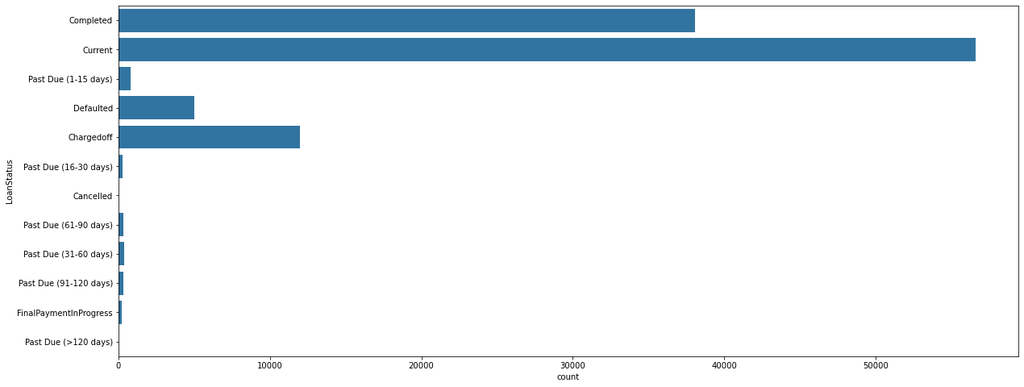

```python
print(df.LoanStatus.value_counts())
sb.countplot(data=df, y = 'LoanStatus', color=sb.color_palette()[0]);
```

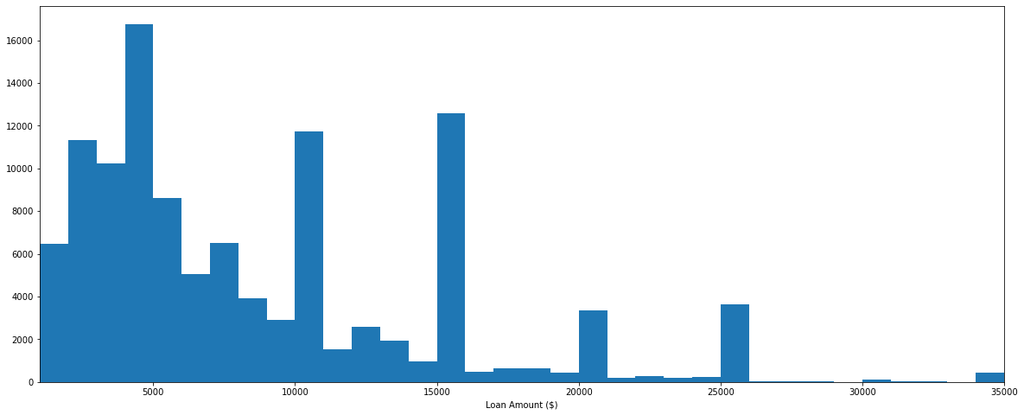

```python
# start with a standard-scaled plot
binsize = 1000
bins = np.arange(df.LoanOriginalAmount.min(), df['LoanOriginalAmount'].max()+binsize, binsize)

plt.hist(data = df, x = 'LoanOriginalAmount', bins = bins)
plt.xlabel('Loan Amount ($)')
plt.xlim([1000,35000])
plt.show()
```

Most of the loans seems to lie between 4k and 10k with one uptick around 16k. Lets zoom into this range and see how its distributed.

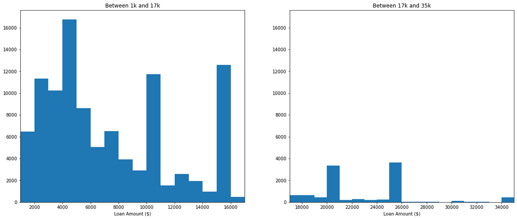

```python
#plot the data with limit between 1k and 10k as well as 17k and 35k
plt.subplot(1,2,1)
plt.title('Between 1k and 17k')
plt.hist(data = df, x = 'LoanOriginalAmount', bins = bins);
plt.xlim([1000,17000])
plt.xlabel('Loan Amount ($)')

plt.subplot(1,2,2)
plt.title('Between 17k and 35k')
plt.hist(data = df, x = 'LoanOriginalAmount', bins = bins);
plt.xlim([17000, 35000])
plt.xlabel('Loan Amount ($)');
```

At the first plot, we can see the peaks at 4k, 10k and 16k with the rest of the values mimicking a downward slope to the right. Second plot shows scanty amount of loans in the higher price range. Lets now look at the distribution of other categorical features (BorrowerState, Occupation, EmploymentStatus and IncomeRange)

```python
# define functions to plot multiple categorical variables and single variables
def plot_categorical_variables(variables, order=None):
    fig, ax = plt.subplots(nrows=len(variables), figsize = [20,20])
    for i in range(len(variables)):
        var = variables[i]
        if var == 'IncomeRange':
            sb.countplot(data = df, y = var, color = sb.color_palette()[0], ax = ax[i], order=order, orient='h')
            continue
        sb.countplot(data = df, y = var, color = sb.color_palette()[0], ax = ax[i])

def plot_one_categorical_var(data, var, orientation=None, hue=None, palette=None, ax=None, color=None):
    sb.countplot(data = data, y = var, color=color, hue=hue, palette=palette, ax=ax) if orientation == 'y' \
    else sb.countplot(data = data, x = var, color=color, hue=hue, palette=palette, ax=ax)
```

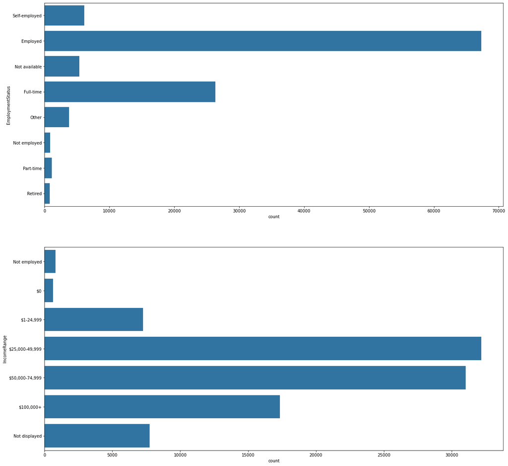

```python
income_range_order = ['Not employed', '$0', '$1-24,999', '$25,000-49,999', '$50,000-74,999', '$100,000+', 'Not displayed']
plot_categorical_variables(['EmploymentStatus', 'IncomeRange'], income_range_order)
```

Since the number of variables in BorrowerState and Occupation feature is large, we will plot them seperately.

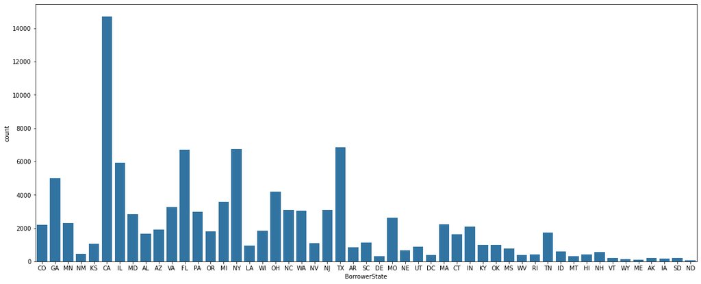

```python
#plot BorrowerState distribution
plot_one_categorical_var(df, 'BorrowerState', orientation='x', color=sb.color_palette()[0])
```

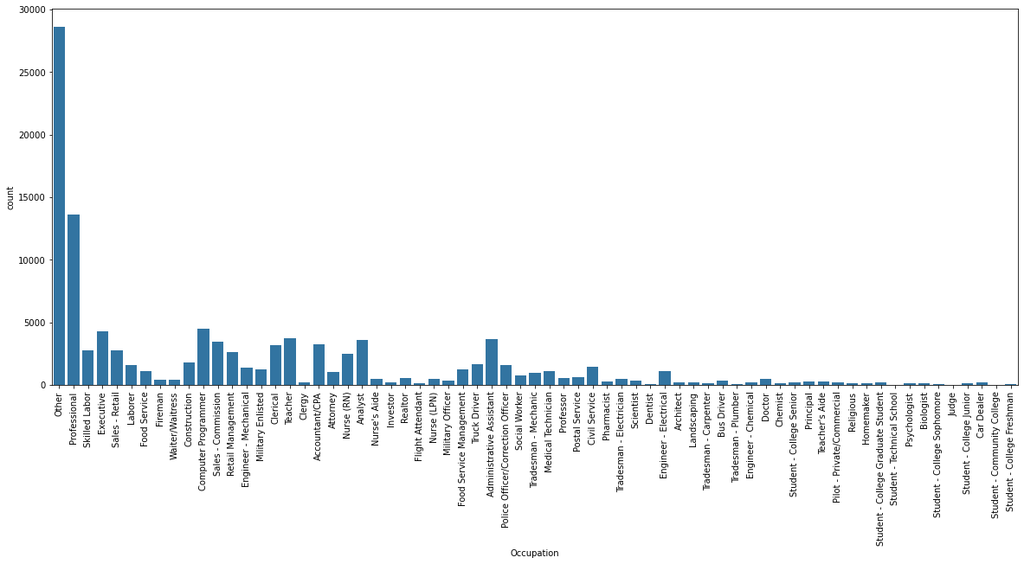

```python
#plot Occupation distribution
plot_one_categorical_var(df, 'Occupation', 'x', color=sb.color_palette()[0])
plt.xticks(rotation=90);
```

Next look at the frequency of reasons people gave for collecting loans

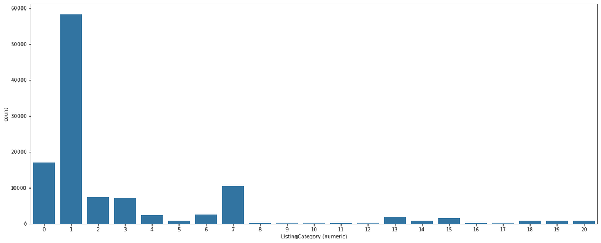

```python
# plot listing category distribution
plot_one_categorical_var(df, 'ListingCategory (numeric)', color=sb.color_palette()[0])
```

According to the plot above, Debt consolidation is the most reason for loans. Could the state of residence be a contributing factor to this high uptick? We'd find out during the bivariate plot session.

Last but not the least in this univariate plot section, lets look at the distribution of prosper score, A custom risk score built using historical Prosper data. The score ranges from 1-11, with 11 being the best, or lowest risk score.

```python
# since this is a ordinal discrete value, lets change the type accordingly
ordered_category = [1.0,2.0, 3.0, 4.0, 5.0, 6.0, 7.0, 8.0, 9.0, 10.0, 11.0]
ordered_var = pd.api.types.CategoricalDtype(ordered = True, categories = ordered_category)
df['ProsperScore'] = df['ProsperScore'].astype(ordered_var)
```

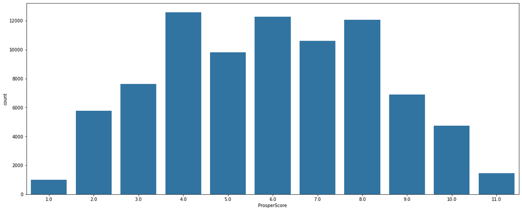

```python
# plot ProsperScore distribution
plot_one_categorical_var(df, 'ProsperScore', color=sb.color_palette()[0])
```

We can see high occurance of loans rated 4.0, 6.0 and 8.0 with the count going downward as we approach high rating. Also there isnt much loans with 1.0 rating. This is the least safe rating.

### Discuss the distribution(s) of your variable(s) of interest. Were there any unusual points? Did you need to perform any transformations?

There is an uptick in 4k, 10k and 16k loan amount. Split the loan amount and zoomed it to get a clearer view of the distribution.

### Of the features you investigated, were there any unusual distributions? Did you perform any operations on the data to tidy, adjust, or change the form of the data? If so, why did you do this?

High number of loans originate from CA and Debt consolidation as a listing category has a very high frequency compared to other categories. No transformations were performed. I'd like to know if there is a correlation.

## Bivariate Exploration

Lets first look at the amount of loan disbursed in each category

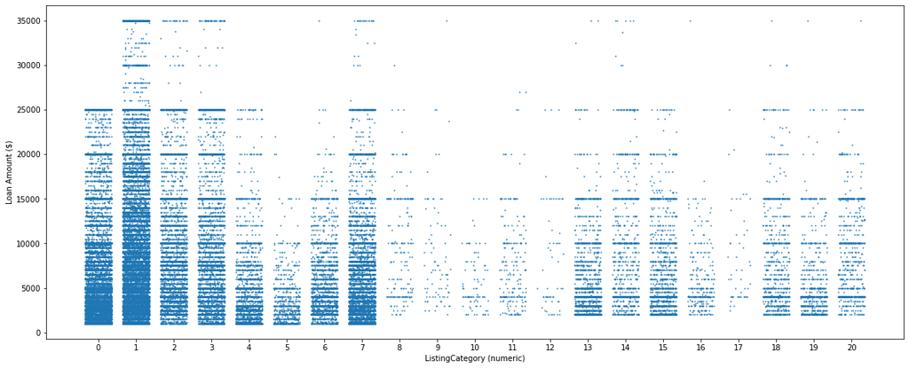

```python
ticks = df['ListingCategory (numeric)'].value_counts().index.sort_values()
sb.regplot(data=df, y='LoanOriginalAmount', x='ListingCategory (numeric)', fit_reg=False, x_jitter=0.35, scatter_kws={'s':1})
plt.xticks(ticks, ticks)
plt.ylabel('Loan Amount ($)');
```

Debt consolidation cuts across the whole original loan amount range. Following closely is home improvement and business. Number zero represents *Not Available* meaning the reason for the loan was not recorded same as 7 which represents *other*. Lets now look at state and listing category

```python
#select non null values of listing category and borrower state
df_select = df.loc[(-df['ListingCategory (numeric)'].isnull()) & (-df.BorrowerState.isnull())]

#get the unique states
states = df_select.BorrowerState.value_counts().index
```

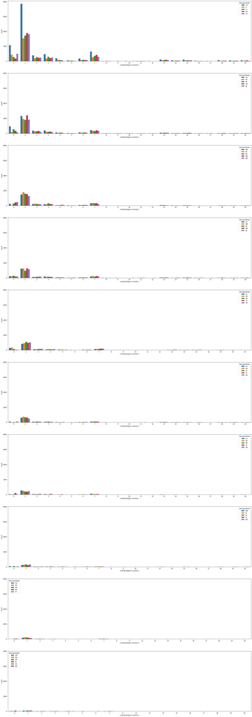

```python
#select the states in chunks of five and plot it
fig, ax = plt.subplots(nrows=10, figsize = [30,90])
count = 0
for i in range(0, len(states), 5):
    x = i
    if x == 45:
        data = df_select.loc[(df_select.BorrowerState.isin(list(states[x:x+6])))]
        plot_one_categorical_var(data, 'ListingCategory (numeric)', hue = 'BorrowerState', ax = ax[count])
        ax[count].set(yticks=range(0,10000, 2000), yticklabels=[i for i in range(0,10000, 2000)])
        break
    data = df_select.loc[(df_select['BorrowerState'].isin(list(states[x:x+5])))]
    plot_one_categorical_var(data, 'ListingCategory (numeric)', hue = 'BorrowerState', ax = ax[count])
    ax[count].set(yticks=range(0,10000, 2000), yticklabels=[i for i in range(0,10000, 2000)])
    count = count + 1
```

As suspected, there is a correlation between listing category and state. California (CA) proves this a count of almost 8k in the aformentioned category. Next lets check out the correleation of numeric features.

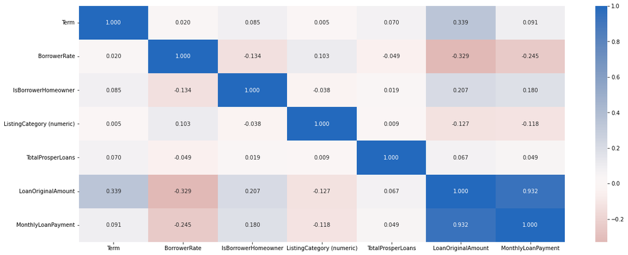

```python
#heatmap plot
sb.heatmap(df.corr(), annot = True, fmt = '.3f', cmap = 'vlag_r', center = 0);
```

We can see the positive correlation between Home owner status and loan amount. There is also some positive correlation between number of prior prosper loans and loan amount. Lets investigate this further.

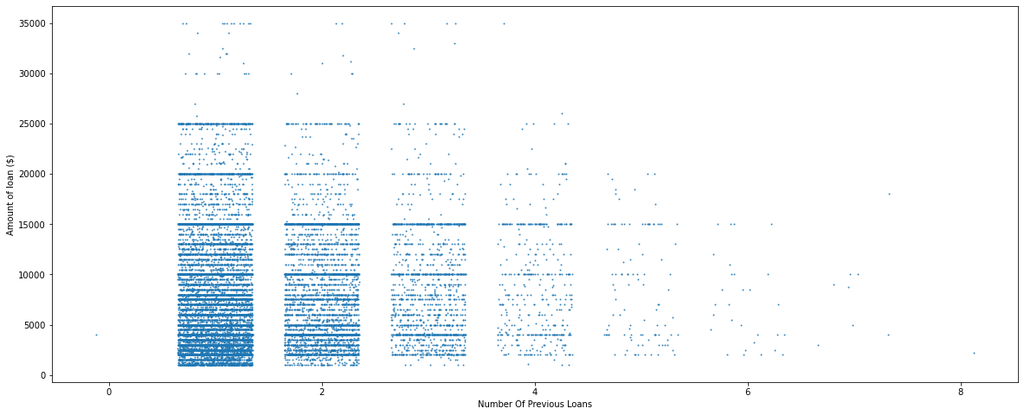

```python
#scatter plot
# plt.scatter(data=df, x='TotalProsperLoans', y='LoanOriginalAmount')
sb.regplot(data=df, x='TotalProsperLoans', y='LoanOriginalAmount', fit_reg=False, x_jitter=0.35, scatter_kws={'s':1})
plt.xlabel('Number Of Previous Loans')
plt.ylabel('Amount of loan ($)');
```

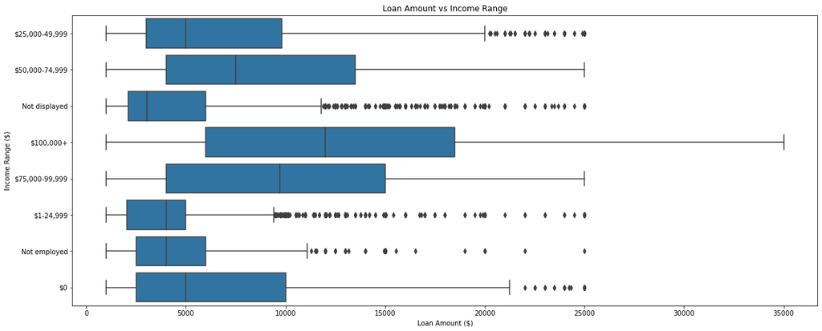

```python
#plot the boxplot
base_color = sb.color_palette()[0]
sb.boxplot(data=df, y='IncomeRange', x='LoanOriginalAmount', color=base_color)
plt.xlabel('Loan Amount ($)')
plt.ylabel('Income Range ($)');
plt.title('Loan Amount vs Income Range');
```

The largest loan amount falls in the 100k+ category with the median value ranging around 12000 in that category and min value(Q1) higher that median value of most income range group. This is not surprising since high income earners poses lesser loan risk hence access to higher loan amount.

[figure not shown]

```python
# plot bar chart of income range against loan amount
sb.barplot(data = df, x = 'IncomeRange', y='LoanOriginalAmount', palette=['steelblue'], order=income_range_order)
plt.title('Distribution of prosper score across income ranges')
plt.xlabel('Income Range ($)');
```

How does proper score fair across income ranges ?

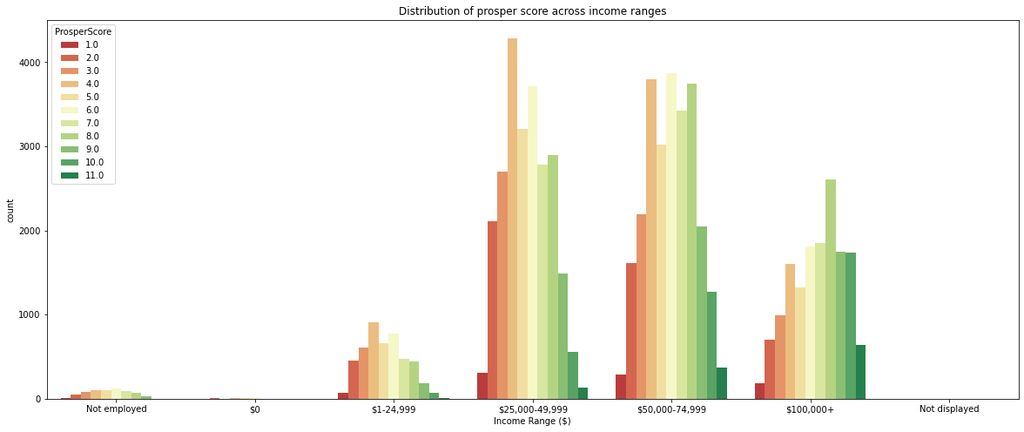

```python
# plot clustered bar chart using prosper score as hue
sb.countplot(data = df, x = 'IncomeRange', hue = 'ProsperScore', palette='RdYlGn', order=income_range_order)
plt.title('Distribution of prosper score across income ranges');
plt.xlabel('Income Range ($)');
```

### Did you observe any interesting relationships between the other features (not the main feature(s) of interest)?

There is correlation between state and reason for loan. Apparently, many people living in california got huge debts that need clearing.

## Multivariate Exploration

Lets look at the prosper score across listing categories and how it fairs against loan amount. Will prominent reasons like debt consolidation get higher prosper score ?

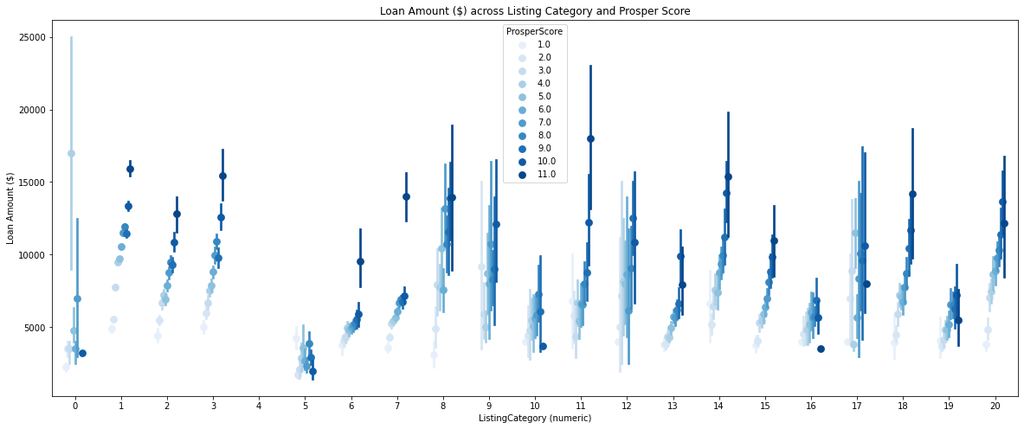

```python
#plot pointplot
sb.pointplot(data=df, y='LoanOriginalAmount', x='ListingCategory (numeric)',hue = 'ProsperScore',
             palette = 'Blues', linestyles = '', dodge = 0.4 )
plt.title('Loan Amount ($) across Listing Category and Prosper Score')
plt.ylabel('Loan Amount ($)');
```

```python
#New loan status variable with fewer groups
df['LoanStatusNew'] = np.where(df.LoanStatus.str.contains('Past Due'), 'Past Due', df.LoanStatus)
loan_status_order = ['Cancelled', 'Completed', 'FinalPaymentInProgress', 'Current', 'Past Due', 'Chargedoff', 'Defaulted']
```

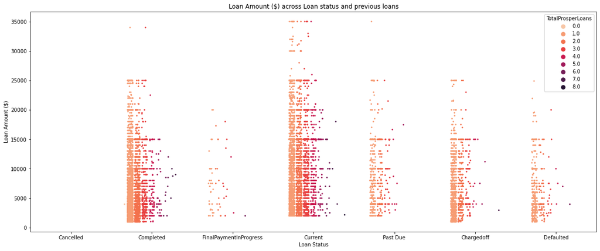

```python
#Scatter plot
plt.figure(figsize=[20,8])
sb.stripplot(data=df, x='LoanStatusNew', y='LoanOriginalAmount', hue ='TotalProsperLoans', palette='rocket_r',
             order=loan_status_order, size=3, jitter=0.3, dodge=True)
plt.ylabel('Loan Amount ($)')
plt.xlabel('Loan Status')
plt.title('Loan Amount ($) across Loan status and previous loans');
```

Most of the borrowers have less that 3 prior loans and many of the loans are currently running and its price range is largely concentrated between 2k and 17k.

### Talk about some of the relationships you observed in this part of the investigation. Were there features that strengthened each other in terms of looking at your feature(s) of interest?

Number of prior loans affect the loan amount and most completed loans are below 15k. Majority of defaulted and charged off loans are also within that price range.

### Were there any interesting or surprising interactions between features?

One would assume that high number of prior completed loans would result to higher credit score and inturn higher loan amount but that is not the case.